# D.U.R.T.

### Base D.U.R.T. Function

D.U.R.T. relys on a base function that scrapes a twitter users timeline for any use of derogatory language. To gain acesses to user’s timelines I use a twitter developer API and the package rtweet. Additionally, I created a list of derogatory words to filter tweets by.

```r
library(rtweet) # refrence the rtweet package
library(tidyverse)
library(tidytext) #refrences some other required packages

APIkey <- "bGX8l5k6rYKMVwiKulsIjfNUK"
APIcode <- "V8sSfll7wrgJxcHNnyCW7xcsNNxN8xjE6VJ21jLNkVqthacofK"
token <- "1120751845213974528-pEBExgwOIk9q4IfQrdbRdFnGGLwRcU"
tokencode <- "7vQvSGvEBWav52EdPcQJC00R97hn11eTa4ko82GcYzvbz"

create_token( app = "DURT", APIkey, APIcode, token, tokencode) #this code accesses our twitter API. Authorization below.
```

```
## <Token>
## <oauth_endpoint>
##  request:   https://api.twitter.com/oauth/request_token
##  authorize: https://api.twitter.com/oauth/authenticate
##  access:    https://api.twitter.com/oauth/access_token
## <oauth_app> DURT
##   key:    bGX8l5k6rYKMVwiKulsIjfNUK
##   secret: <hidden>
## <credentials> oauth_token, oauth_token_secret
## ---
```

```r
durtwords <- c('bitch','bitches','Bitch','Bitches', 'bitched','fuck', 'Fuck', 'FUCK', 'fucking', 'fucked', 'fucker', 'Fucked', 'Fucker', 'Fuckers', 'Cunt', 'cunt', 'CUNT', 'fag','FAG','Fag', 'faggot', 'Faggot', 'faggit', 'Faggit', 'Faggot', 'NIGGER','Nigger', 'nigger', 'Nigga', 'NIGGA', 'Nigga', 'Ass', 'ass', 'ASS', 'Bastard', 'BASTARD',
'bastard', 'Slut', 'SLUT', 'slut', 'WHORE', 'Whore', 'whore', 'skank', 'Skank', 'WHORE', 'porn', 'Porn', 'PORN', 'Vagina', 'VAGINA', 'vagina', 'dick', 'Dick', 'DICK', 'Pussy', 'PUSSY', 'pussy', 'penis', 'Penis', 'PENIS','Gay', 'GAY', 'gay','NIGGERS', 'niggas', 'niggers', 'NIGGAS', 'Gay', 'gays', 'GAYS', 'Gays', 'fags', 'Fags', 'Faggots','shit', 'SHIT', 'Shit', 'Shits', 'shits', 'Mexican', 'mexican', 'mexicans', 'Mexicans', 'Jew', 'Jews', 'jew', 'jews', 'spic', 'COCK', 'cock', 'cocks', 'Cock','retard', 'Retard', 'Retarded','retarded', 'chode', 'Chode', 'Cum', 'CUM', 'cum', 'Weed', 'weed', 'crack', 'Crack', 'Coke', 'coke', 'blow', 'Blow', 'ayo', 'yayo','alc', 'beer','Beer', 'Twat', 'twat', 'TWAT', 'prick', 'Prick', 'FUCKER', 'clit', 'Clit', 'CLIT', 'Jizz', 'jizz', 'sex', 'Sex', 'SEX', 'queef', 'Queef',
'blowjob', 'Blowjob', 'handjob', 'Handjob', 'choad', 'Choad', 'Tits', 'tits', 'TITS', 'Titties', 'titties', 'tiddies', 'Boobs', 'boobs', 'balls', 'Balls', 'ballsack', 'Ballsack', 'Piss', 'piss', 'Taint', 'taint', 'Pubes', 'pubes', 'nutsack', 'Nutsack', 'Spick', 'Spick', 'wetback', 'Terrorist', 'terrorist', 'LSD', 'Acid', 'acid', 'Nazi', 'nazi', 'NAZIS', 'NAZI', 'nazis', 'Dyke', 'dyke', 'Dike', 'dike', 'Coon', 'coon', 'COON', 'DIKE', 'DYKE', 'queer', 'Queer', 'trans', 'tranny','Tranny', 'NIG', 'nig', 'Nig', 'Lesbian', 'lesbian', 'Lesbo', 'lesbian', 'Redneck', 'redneck', 'Raghead', 'raghead', 'fat', 'FAT', 'Fat', 'towelhead', 'Towelhead', 'blunt', 'Blunt', 'Joint', 'joint') #defining durty words

getdurt <- function(name) {

tweets <- get_timeline(name , n = 100000)

durt <- tweets %>%
  select(status_id, text) %>%
  unnest_tokens(word, text) %>%
  filter(word %in% durtwords) %>%
  select(status_id) %>%
  left_join(tweets, durt, by = NULL)

data.frame(durt)
} #defining the base function. this function does the gritty work for our app.
```

### Applying D.U.R.T.

```r
top50highschool <- c('SmithNoland2', 'kayvonT8', 'JrStingley', 'jadon_haselwood', 'Antonioalfano99', '6sixGod_', 'ENeal73', 'ZP62019', 'buhbuhbru', 'darnell_5232', 'SpencerRattler','zacharrison_', 'Emery4____',  'daxhill5', 'K_Green_01', 'boimarv9', 'loganbrown53', 'brand0n_smith12', 'KobeDean2', 'GarrettWilson_V', '_TheoWeaseJr','D1Figure_', 'andrewbooth21', 'geo_Thagoat', 'opfreak15', 'claywebbG3', 'CharlesCross67', 'wanyamorris64', 'ealy_1k', 'h_miller76', 'Thechrishinton','MarcelBrooks_5', 'bo_nix10', 'J_Whitt3', 'JayD__5', 'domblaylock_1', 'dreamchaserTy10', 'Ford_Kyle6', '_FrankLadson', 'PierceQuick', '_mykael2','KinggChris7', 'jordantofly100', 'HenryTootoo1', 'LewisCine', 'zachcharbon', 'isopsher', 'Easymoney_Kai', 'jakesmith27', 'DoItAllDent103')

top50draft <- c('TheKylerMurray', 'nbsmallerbear', 'QuinnenWilliams' ,'Cle_Missile' ,'DevinWhite__40' ,'Daniel_Jones10' ,'JoshAllen41_' ,'TheeHOCK8' ,'Edoliver_11' ,'_Dbush11' ,'JonahGWilliams','RashanAGary','cwilkins42' ,'Big_Fish75','dh_simba7' ,'Fire_Burns99','llawrence2139','Gbradbury_11','GrindSimmons94','nrfant','darnellsavage_' ,'AndreDillard_','levelstothis_2' ,'iAM_JoshJacobs' ,'Primetime_jet' ,'_sweat9','JohnathanAbram1','JerryTillery','ljcollier91','DreBaker1_','KalebMcgary','NkealHarry15','byronmurphy','Rock_152','jawaan_taylor74','Uno_Captain','Thegreglittle','Cody_Ford74','MrSeanyB1','MullenIsland1','DaltonBigD71','DrewLock23','tavai31','Big_E_14','JoejuanW','Greedy','Erik_McCoy_73','benbanogu','swervinirvin_')

#created lists with top 50 highscoolers and top 50 drafties

hsdurt <- read_csv('highschooldurt.csv')
draftdurt <- read_csv('draftdurt.csv')

hsdurtclean <- hsdurt %>%
select(created_at, screen_name, name, location, status_url, text, is_retweet, favorite_count, retweet_count, retweet_name, retweet_location, profile_image_url)

draftdurtclean <- draftdurt %>%
select(created_at, screen_name, name, location, status_url, text, is_retweet, favorite_count, retweet_count, retweet_name, retweet_location, profile_image_url)

#cleaned the data
```

### Who is the DURTiest?

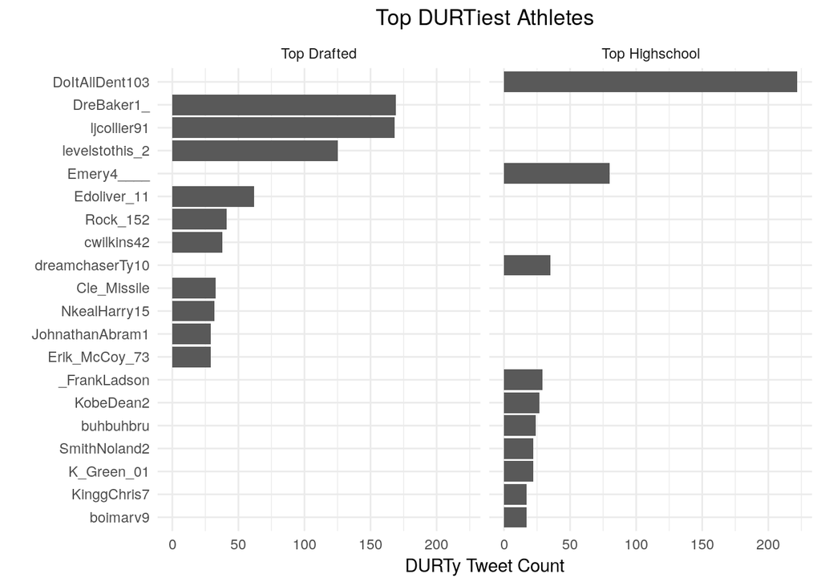

```r
hsdurtiest <- hsdurtclean %>%
  group_by(screen_name) %>%
  count(name) %>%
  arrange(-n) %>%
  mutate(level = 'Top Highschool')
hsdurtiest <- hsdurtiest[1:10,]

draftdurtiest <- draftdurt %>%
  group_by(screen_name) %>%
  count(name) %>%
  arrange(-n) %>%
  mutate(level = 'Top Drafted')
draftdurtiest <- draftdurtiest[1:10,]

alldurtiest <- rbind(hsdurtiest, draftdurtiest)

#data cleaning and combining

#install.packages('plotly')
library(plotly)  #refrence plotly package to display plots

ggplot(alldurtiest, aes(x = reorder(screen_name, n), y = n)) +
  geom_bar(stat = 'identity') +
  facet_wrap(~level) +
  coord_flip() +
  theme_minimal() + xlab('') + ylab('DURTy Tweet Count') +
  ggtitle('Top DURTiest Athletes') + theme(plot.title = element_text(hjust = 0.5)) #build ggplot
```

### How old are DURTy tweets?

To test the belief that NFL drafties have significantly older DURT than the top highschool recruits. The following code displays a timeline of DURTy tweets.

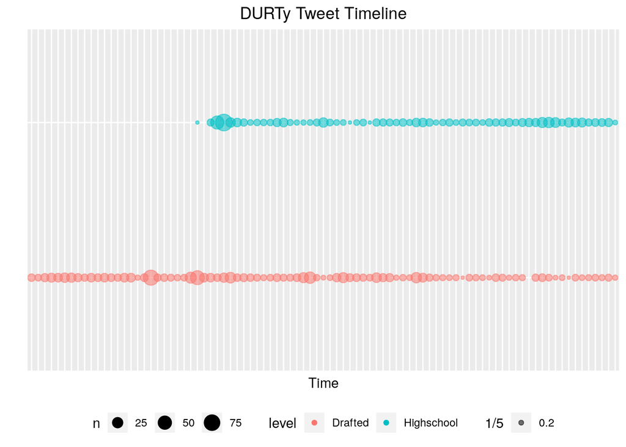

```r
hsdurtydate <- hsdurtclean %>%
  separate(created_at, into = 'Date', sep = ' ') %>%
  separate(Date, into = c('year', 'month'), sep = '-' ) %>%
  unite('year_month', c('year', 'month'), sep =  '-') %>%
  group_by(year_month) %>%
  count(year_month) %>%
  mutate(level = 'Highschool')

draftdurtydate <- draftdurtclean %>%
  separate(created_at, into = 'Date', sep = ' ') %>%
  separate(Date, into = c('year', 'month'), sep = '-' ) %>%
  unite('year_month', c('year', 'month'), sep =  '-') %>%
  group_by(year_month) %>%
  count(year_month) %>%
  mutate(level = 'Drafted')

durt_dates <- rbind(draftdurtydate, hsdurtydate)
#cleaned data

ggplot(durt_dates, aes(alpha = 1/5)) + geom_point(aes(x = year_month, y = level, size = n, color = level)) + theme(plot.title = element_text(hjust = .5), axis.text = element_blank(), axis.ticks = element_blank()) + ggtitle('DURTy Tweet Timeline') + xlab('Time') + ylab('') + theme(legend.position="bottom", legend.box = "horizontal") #creating the graph. Refrenced rdrr.io to clean up axis.
```

### Which DURTy words are used the most?

The following wordcloud displays the DURTy words used most often from both athlete groups. These words were used over 2000 times. While somewords are not as bad when used in their context, most words included are unprofessional and unexeceptable irregardless of context.

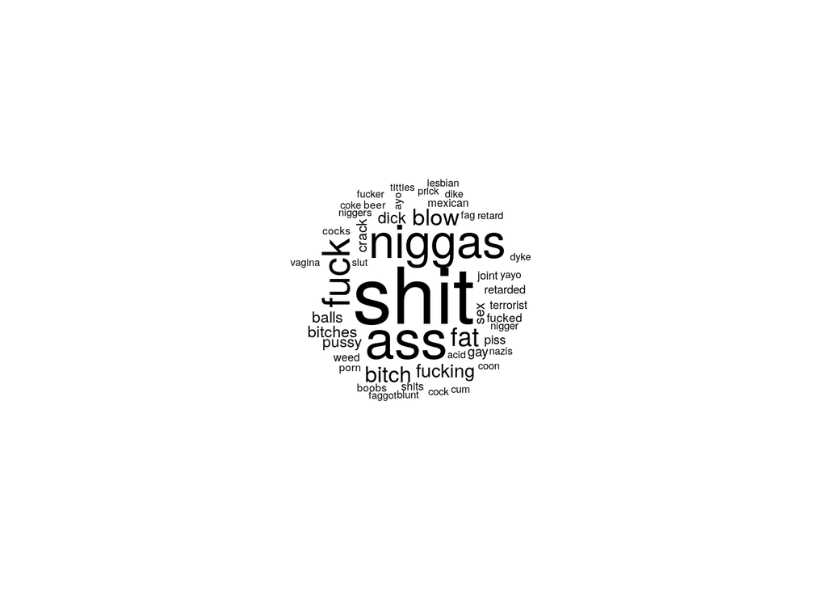

```r
library(wordcloud) #refrencing package wordcloud
library(tm) #refrencing pacakge tm

hsmostwords <- hsdurtclean %>%
  unnest_tokens(word, text) %>%
  filter(word %in% durtwords) %>%
  select(word)
draftmostwords <- draftdurtclean %>%
  unnest_tokens(word, text) %>%
  filter(word %in% durtwords) %>%
  select(word)

allmostdurt <- rbind(hsmostwords, draftmostwords)
# cleaned and combined data

wordcloud(words = allmostdurt$word, min.freq = 1, max.words = Inf, random.order = FALSE) #created wordcloud
```

For a more exact comparison refrence the bar chart below.

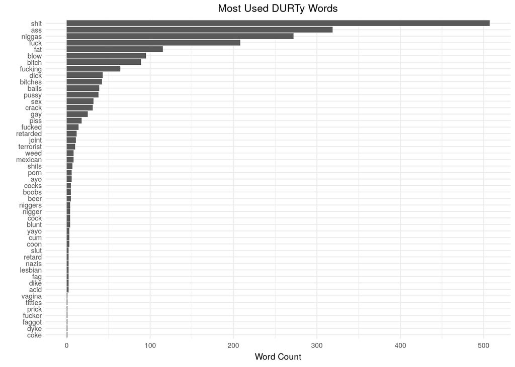

```r
allmostdurtplot <- allmostdurt %>%
  count(word)
# aggregated data

ggplot(allmostdurtplot, aes(x = reorder(word, n), y = n)) + geom_bar(stat = 'identity') + coord_flip() + theme_minimal(base_size = 8.5) + xlab('') + ylab('Word Count') + theme(plot.title = element_text(hjust = 0.5)) + ggtitle('Most Used DURTy Words')
```

### Accuracy & Context

To check the extent that context may skew results, we randomly sampled 100 data points. Of these data points, only 8% were taken completely out of context. The other 92% were derogatory or unprofessional. Because our list of derogatory terms is expansive and generally consists of all negative terms, context does not drastically effect our results. Therefore, the research on top football atheletes is generally accurate.

##### Refrences

As cited throughout my code, I refrenced the following sources. Additionally, Mason Kreuger (USMA '21) provided me with feedback and assistance throughouttthis preliminary study.

- https://rtweet.info/
- https://github.com/ropensci/plotly/issues/1049
- https://stackoverflow.com/questions/47193192/r-markdown-and-plotly-fig-align-not-working-with-html-output
- https://rdrr.io/cran/ggpubr/man/rremove.html
- http://www.sthda.com/english/wiki/text-mining-and-word-cloud-fundamentals-in-r-5-simple-steps-you-should-know#step-1-create-a-text-file
- https://stackoverflow.com/questions/43404487/how-do-i-center-my-yaml-heading-in-an-r-markdown-html-document
- https://cran.r-project.org/web/packages/wordcloud/index.html
- http://shiny.rstudio.com/gallery/ +https://stackoverflow.com/questions/50429119/sidebarmenu-does-not-function-properly-when-using-includehtml/50820737#50820737